# Using Python for Data Mining

November 7, 2015

## Using Python for Data Mining

How you get some data from a database, play with it and gain some insights with Python.

Slides can be obtained here:

http://github.com/christlc/pycon2015hk

1. Get started in Python
2. Be a Database Explorer
3. Data wrangling - SQLAlchemy and Pandas
4. Using R style formula in regression.

## Get started in Python

## Install Python and associated packages quickly

To get a Python data mining environment setup quickly, https://www.continuum.io/downloads

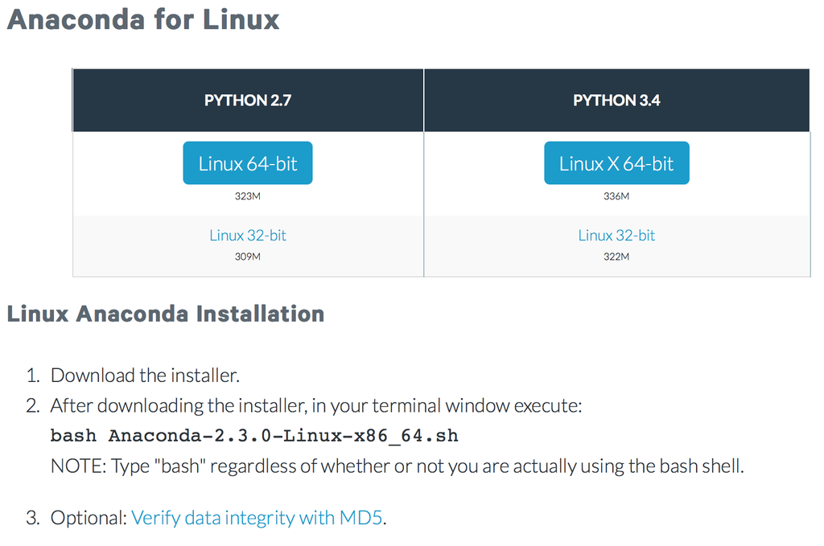

1. All the basic packages included, e.g. SQLAlchemy, ipython, pandas, numpy, statsmodel.
2. No admin rights required under Linux/Mac.
3. No compilation required.

## IPython(Jupyter) notebook

Fire up ipython notebook and you can get an interactive data analysis environment.

[figure not shown]

```bash
ipython notebook
```

## Be a Database Explorer

## Reflect database schema

What is the database structure?

- Time to use SQLAlchemy

```python
import sqlalchemy

# http://docs.sqlalchemy.org/en/rel_1_0/core/engines.html
engine = sqlalchemy.create_engine('sqlite:///flightdata.sqlite3')
meta = sqlalchemy.MetaData()
meta.reflect(bind=engine)
print(meta.tables.keys())
```

```
Python> [u'flights', u'sqlite_stat1']
```

- There is a table called *flight*.

## What's the table like?

```python
print(meta.tables['flights'])
```

Table('flights', MetaData(bind=None),  
Column('year', INTEGER(), table=),  
Column('month', INTEGER(), table=),  
Column('day', INTEGER(), table=),  
Column('dep_time', INTEGER(), table=),  
Column('dep_delay', REAL(), table=),  
Column('carrier', TEXT(), table=),  
…

## Lets download the data

- We can then quickly download the data as Pandas dataframe.

```python
import pandas as pd
alldata = pd.read_sql(
  'select * from flights',
  engine)
```

|  | year | month | day | carrier | dep_delay |
| --- | --- | --- | --- | --- | --- |
| 0 | 2013 | 1 | 1 | UA | 2 |
| 1 | 2013 | 1 | 1 | UA | 4 |
| 2 | 2013 | 1 | 1 | AA | 2 |
| 3 | 2013 | 1 | 1 | B6 | -1 |
| 4 | 2013 | 1 | 1 | DL | -6 |

- Effectively an SQL explorer.

## What is the longest delay?

[figure not shown]

By Omar Parada (Under CC license) Flickr

## Pandas

Pandas provides data structure like DataFrame and a set of functions to transform the data.

```python
# First load all the data into a dataframe
alldata = pd.read_sql('select * from flights',
                      engine)

# Sort according to departure delay
# and show the first 10 rows
alldata.sort('dep_delay',ascending=False).head(10)
```

|  | year | month | day | carrier | dep_delay |
| --- | --- | --- | --- | --- | --- |
| 7072 | 2013 | 1 | 9 | HA | 1301 |
| 235778 | 2013 | 6 | 15 | MQ | 1137 |
| 8239 | 2013 | 1 | 10 | MQ | 1126 |
| 327043 | 2013 | 9 | 20 | AA | 1014 |
| 270376 | 2013 | 7 | 22 | MQ | 1005 |
| 173992 | 2013 | 4 | 10 | DL | 960 |
| 151974 | 2013 | 3 | 17 | DL | 911 |
| 247040 | 2013 | 6 | 27 | DL | 899 |
| 270987 | 2013 | 7 | 22 | DL | 898 |
| 87238 | 2013 | 12 | 5 | AA | 896 |

## SQLAlchemy expression

```python
from sqlalchemy.sql import select, func
flights_table = meta.tables['flights']
myquery = select([flights_table])
myquery = myquery.order_by(flights_table.c.dep_delay.desc())
myquery = myquery.limit(10)
pd.read_sql(myquery, engine)
```

|  | year | month | day | carrier | dep_delay |
| --- | --- | --- | --- | --- | --- |
| 0 | 2013 | 1 | 9 | HA | 1301 |
| 1 | 2013 | 6 | 15 | MQ | 1137 |
| 2 | 2013 | 1 | 10 | MQ | 1126 |
| 3 | 2013 | 9 | 20 | AA | 1014 |
| 4 | 2013 | 7 | 22 | MQ | 1005 |
| 5 | 2013 | 4 | 10 | DL | 960 |
| 6 | 2013 | 3 | 17 | DL | 911 |
| 7 | 2013 | 6 | 27 | DL | 899 |
| 8 | 2013 | 7 | 22 | DL | 898 |
| 9 | 2013 | 12 | 5 | AA | 896 |

## SQLAlchemy expression (continuted)

Equivalent to running:

```python
pd.read_sql('select * from flights order by dep_delay desc limit 10',
            engine)
```

## R-style formula in regression

## Which day of week to avoid delay

Aim:

Fit a model to determine which day of week (Monday, Tuesday, …, Sunday) would be best to avoid delay.

Our plan:

1. Define "late" as a new column
2. Compute the proportion of flights delayed by day
3. Tag Mon, Tue, …
4. Fit a linear regression with day of week as a factor.

## Prepare data

1. Define late as departure 30 minutes later than scheduled
2. Convert year, month, day into a single date field

```python
from datetime import datetime
# Define late as departure 30 minutes later than expected
alldata['is_late'] = (alldata['dep_delay']>30)
# Convert year, month, day into a datetime object
alldata['date'] = alldata.apply(
    lambda x: datetime(x.year,x.month,x.day).date(), axis=1)
```

|  | year | month | day | carrier | dep_delay | is_late | date |
| --- | --- | --- | --- | --- | --- | --- | --- |
| 1 | 2013 | 1 | 1 | UA | 4 | 0 | 2013-01-01 |
| 2 | 2013 | 1 | 1 | AA | 2 | 0 | 2013-01-01 |
| 85 | 2013 | 1 | 1 | UA | 47 | 1 | 2013-01-01 |
| 96 | 2013 | 1 | 1 | MQ | 39 | 1 | 2013-01-01 |

## Group by date

```python
# Compute the proportion of flights late on each day
late_df = alldata.groupby('date')['is_late'].mean().reset_index()
print(late_df)
```

|  | date | is_late |
| --- | --- | --- |
| 0 | 2013-01-01 | 0.125891 |
| 1 | 2013-01-02 | 0.150583 |
| 2 | 2013-01-03 | 0.132385 |
| 3 | 2013-01-04 | 0.118033 |
| 4 | 2013-01-05 | 0.0694444 |
| 5 | 2013-01-06 | 0.100962 |
| 6 | 2013-01-07 | 0.0803859 |
| 7 | 2013-01-08 | 0.0589544 |
| 8 | 2013-01-09 | 0.0432373 |
| 9 | 2013-01-10 | 0.0536481 |

## Tag day of week

```python
# Tag the date with a dayofweek tag
late_df['dayofweek'] = late_df['date'].map(lambda x: x.isoweekday())
print(late_df)
```

|  | date | is_late | dayofweek |
| --- | --- | --- | --- |
| 0 | 2013-01-01 | 0.125891 | 2 |
| 1 | 2013-01-02 | 0.150583 | 3 |
| 2 | 2013-01-03 | 0.132385 | 4 |
| 3 | 2013-01-04 | 0.118033 | 5 |
| 4 | 2013-01-05 | 0.0694444 | 6 |
| 5 | 2013-01-06 | 0.100962 | 7 |
| 6 | 2013-01-07 | 0.0803859 | 1 |
| 7 | 2013-01-08 | 0.0589544 | 2 |
| 8 | 2013-01-09 | 0.0432373 | 3 |
| 9 | 2013-01-10 | 0.0536481 | 4 |

## Specify a regression model using formula

```python
import statsmodels.formula.api as smf
mod = smf.ols(formula=' is_late ~ C(dayofweek)', data=late_df)
res = mod.fit()
print(res.summary())
```

## Regression summary

| coefficient | coef | std err | t | P>\|t\| | [95.0% Conf. Int.] |
| --- | --- | --- | --- | --- | --- |
| Intercept | 0.1583 | 0.012 | 12.809 | 0.000 | 0.134 0.183 |
| C(dayofweek)[T.2] | -0.0269 | 0.017 | -1.547 | 0.123 | -0.061 0.007 |
| C(dayofweek)[T.3] | -0.0236 | 0.017 | -1.352 | 0.177 | -0.058 0.011 |
| C(dayofweek)[T.4] | 0.0119 | 0.017 | 0.680 | 0.497 | -0.022 0.046 |
| C(dayofweek)[T.5] | 0.0018 | 0.017 | 0.104 | 0.917 | -0.033 0.036 |
| C(dayofweek)[T.6] | -0.0595 | 0.017 | -3.406 | 0.001 | -0.094 -0.025 |
| C(dayofweek)[T.7] | -0.0254 | 0.017 | -1.453 | 0.147 | -0.060 0.009 |

## Interpretation

Saturday has significantly fewer delays than Monday.

## Questions?

## Extra: do it with dplyr in R

SQLAlchemy in Python vs dplyr in R

```r
library(dplyr)
flightdb <- src_sqlite("./flightdata.sqlite3")
flight_table <- tbl(flightdb, "flights")
flight_table %>%
  arrange(desc(dep_delay)) %>% head(10)
```

| year | month | day | carrier | dep_delay |
| --- | --- | --- | --- | --- |
| 2013 | 1 | 9 | HA | 1301 |
| 2013 | 6 | 15 | MQ | 1137 |
| 2013 | 1 | 10 | MQ | 1126 |
| 2013 | 9 | 20 | AA | 1014 |
| 2013 | 7 | 22 | MQ | 1005 |
| 2013 | 4 | 10 | DL | 960 |
| 2013 | 3 | 17 | DL | 911 |
| 2013 | 6 | 27 | DL | 899 |
| 2013 | 7 | 22 | DL | 898 |
| 2013 | 12 | 5 | AA | 896 |

## Extra - Comparing other day of week

```python
mod = smf.ols(formula=' is_late ~ C(dayofweek, levels=[6,1,2,3,4,5,7])',
              data=late_df)
res = mod.fit()
print(res.summary())
```

| coefficient | coef | std err | t | P>\|t\| | [95.0% Conf. Int.] |
| --- | --- | --- | --- | --- | --- |
| Intercept | 0.0988 | 0.012 | 7.992 | 0.000 | 0.074 0.123 |
| C(dayofweek, levels=[6, 1, 2, 3, 4, 5, 7])[T.1] | 0.0595 | 0.017 | 3.406 | 0.001 | 0.025 0.094 |
| C(dayofweek, levels=[6, 1, 2, 3, 4, 5, 7])[T.2] | 0.0326 | 0.017 | 1.875 | 0.062 | -0.002 0.067 |
| C(dayofweek, levels=[6, 1, 2, 3, 4, 5, 7])[T.3] | 0.0359 | 0.017 | 2.054 | 0.041 | 0.002 0.070 |
| C(dayofweek, levels=[6, 1, 2, 3, 4, 5, 7])[T.4] | 0.0714 | 0.017 | 4.086 | 0.000 | 0.037 0.106 |
| C(dayofweek, levels=[6, 1, 2, 3, 4, 5, 7])[T.5] | 0.0613 | 0.017 | 3.510 | 0.001 | 0.027 0.096 |
| C(dayofweek, levels=[6, 1, 2, 3, 4, 5, 7])[T.7] | 0.0341 | 0.017 | 1.953 | 0.052 | -0.000 0.069 |

## Extra - Diagnostics

[Quantile-Quantile plots](https://en.wikipedia.org/wiki/Q???Q_plot) to check normality of the residuals.

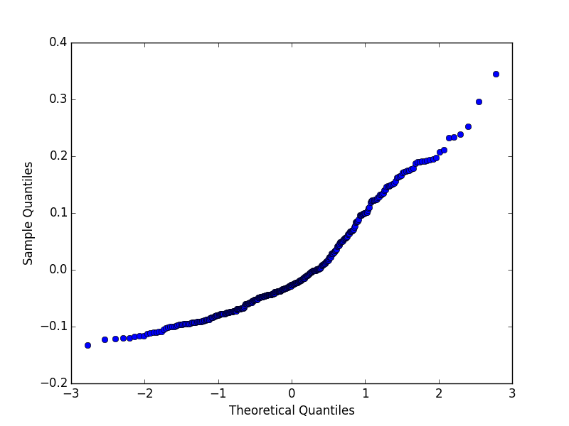

```python
import statsmodels.api as sm
from matplotlib import pyplot as plt
fig = sm.qqplot(res.resid)
plt.show()
```

## Exercise

The residuals are not quite normal.

Exercise: taking log would help.

```python
mod = smf.ols(formula=' np.log(is_late) ~ C(dayofweek)',
              data=late_df)
```